# chapter5.Rmd

AapoVir

2022-11-30

```r
library(readr)
human<-read_csv("data/human.csv")
names(human)
```

```
## [1] "Edu2.FM"   "Labo.FM"   "Edu.Exp"   "Life.Exp"  "GNI"       "Mat.Mor"
## [7] "Ado.Birth" "Parli.F"
```

```r
str(human)
```

```
## spc_tbl_ [155 × 8] (S3: spec_tbl_df/tbl_df/tbl/data.frame)
##  $ Edu2.FM  : num [1:155] 1.007 0.997 0.983 0.989 0.969 ...
##  $ Labo.FM  : num [1:155] 0.891 0.819 0.825 0.884 0.829 ...
##  $ Edu.Exp  : num [1:155] 17.5 20.2 15.8 18.7 17.9 16.5 18.6 16.5 15.9 19.2 ...
##  $ Life.Exp : num [1:155] 81.6 82.4 83 80.2 81.6 80.9 80.9 79.1 82 81.8 ...
##  $ GNI      : num [1:155] 64992 42261 56431 44025 45435 ...
##  $ Mat.Mor  : num [1:155] 4 6 6 5 6 7 9 28 11 8 ...
##  $ Ado.Birth: num [1:155] 7.8 12.1 1.9 5.1 6.2 3.8 8.2 31 14.5 25.3 ...
##  $ Parli.F  : num [1:155] 39.6 30.5 28.5 38 36.9 36.9 19.9 19.4 28.2 31.4 ...
##  - attr(*, "spec")=
##   .. cols(
##   ..   Edu2.FM = col_double(),
##   ..   Labo.FM = col_double(),
##   ..   Edu.Exp = col_double(),
##   ..   Life.Exp = col_double(),
##   ..   GNI = col_double(),
##   ..   Mat.Mor = col_double(),
##   ..   Ado.Birth = col_double(),
##   ..   Parli.F = col_double()
##   .. )
##  - attr(*, "problems")=<externalptr>
```

# Dimensionality reduction techniques

## Overview of the Human data

The Human data is a composite of two joined data sets: the Human Development Index (HDI) data and Gender Inequality Index (GII) data. The HDI and GII data originate from the United Nations Development Programme (UNDP).

#### Human Development Index (HDI)

The UNDP created the HDI emphasize that people and their capabilities should be the ultimate criteria for assessing the development of a country, not economic growth alone. The HDI takes into account a nation’s longevity, education and income. The health dimension is assessed by life expectancy at birth, the education dimension is measured by mean of years of schooling for adults aged 25 years and more and expected years of schooling for children of school entering age. The standard of living dimension is measured by gross national income per capita.

#### Gender Inequality Index (GII)

GII is a composite metric of gender inequality using three dimensions: reproductive health, empowerment and the labour market. The indicators of the reproductive health dimension are maternal mortality ratio and adolescent birth rate. The indicators of the empowerment dimension are proportions of women and men with at least secondary education and the shares of parliamentary seats. Ther indicator of the labour market dimension is the labour force participation rate for women and men.

#### Variable descriptions

- There are 155 observations in the data.
- Human data set contains the following variables:
- Edu2.FM = The ratio of women to men with at least secondary education
- Labo.FM = The ratio of women to men participating in the labour force
- Edu.Exp = Mean years of schooling for adults aged 25 years or more and expected years of schooling for children of school entering age
- Life.Exp = Life expectancy at birth
- GNI = Gross national income per capita
- Mat.Mor = Maternal mortality meaning the death of a woman during pregnancy, at delivery, or soon after delivery
- Ado.Birth = Adolescent giving birth
- Parli.F = Share of women holding parliamentary seats

#### Variable characteristics and distributions

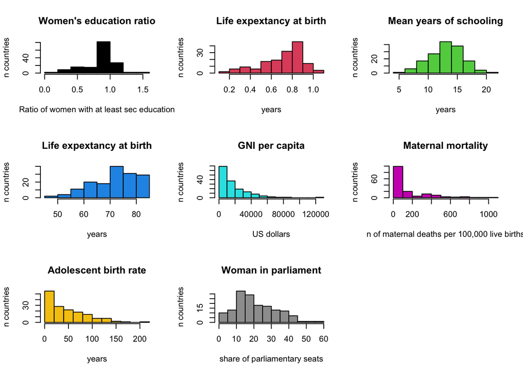

```r
#Histogram
par(mfrow=c(3,3))
hist(human$Edu2.FM,col = 1, main = paste("Women's education ratio"), xlab= "Ratio of women with at least sec education", ylab = "n countries")
hist(human$Labo.FM,col = 2, main = paste("Life expextancy at birth"), xlab= "years", ylab = "n countries")
hist(human$Edu.Exp,col = 3, main = paste("Mean years of schooling"), xlab= "years", ylab = "n countries")
hist(human$Life.Exp,col = 4, main = paste("Life expextancy at birth"), xlab= "years", ylab = "n countries")
hist(human$GNI,col = 5, main = paste("GNI per capita"), xlab= "US dollars", ylab = "n countries")
hist(human$Mat.Mor,col = 6, main = paste("Maternal mortality"), xlab= "n of maternal deaths per 100,000 live births", ylab = "n countries")
hist(human$Ado.Birth,col = 7, main = paste("Adolescent birth rate"), xlab= "years", ylab = "n countries")
hist(human$Parli.F,col = 8, main = paste("Woman in parliament"), xlab= "share of parliamentary seats", ylab = "n countries")
```

```r
library(tidyr); library(dplyr); library(ggplot2)
library(ggplot2)
library(GGally)
library(corrplot)
library(readr)

#Download data
human<-read_csv("data/human.csv")
#Take a summary of the data
summary(human)
```

```
##     Edu2.FM          Labo.FM          Edu.Exp         Life.Exp
##  Min.   :0.1717   Min.   :0.1857   Min.   : 5.40   Min.   :49.00
##  1st Qu.:0.7264   1st Qu.:0.5984   1st Qu.:11.25   1st Qu.:66.30
##  Median :0.9375   Median :0.7535   Median :13.50   Median :74.20
##  Mean   :0.8529   Mean   :0.7074   Mean   :13.18   Mean   :71.65
##  3rd Qu.:0.9968   3rd Qu.:0.8535   3rd Qu.:15.20   3rd Qu.:77.25
##  Max.   :1.4967   Max.   :1.0380   Max.   :20.20   Max.   :83.50
##       GNI            Mat.Mor         Ado.Birth         Parli.F
##  Min.   :   581   Min.   :   1.0   Min.   :  0.60   Min.   : 0.00
##  1st Qu.:  4198   1st Qu.:  11.5   1st Qu.: 12.65   1st Qu.:12.40
##  Median : 12040   Median :  49.0   Median : 33.60   Median :19.30
##  Mean   : 17628   Mean   : 149.1   Mean   : 47.16   Mean   :20.91
##  3rd Qu.: 24512   3rd Qu.: 190.0   3rd Qu.: 71.95   3rd Qu.:27.95
##  Max.   :123124   Max.   :1100.0   Max.   :204.80   Max.   :57.50
```

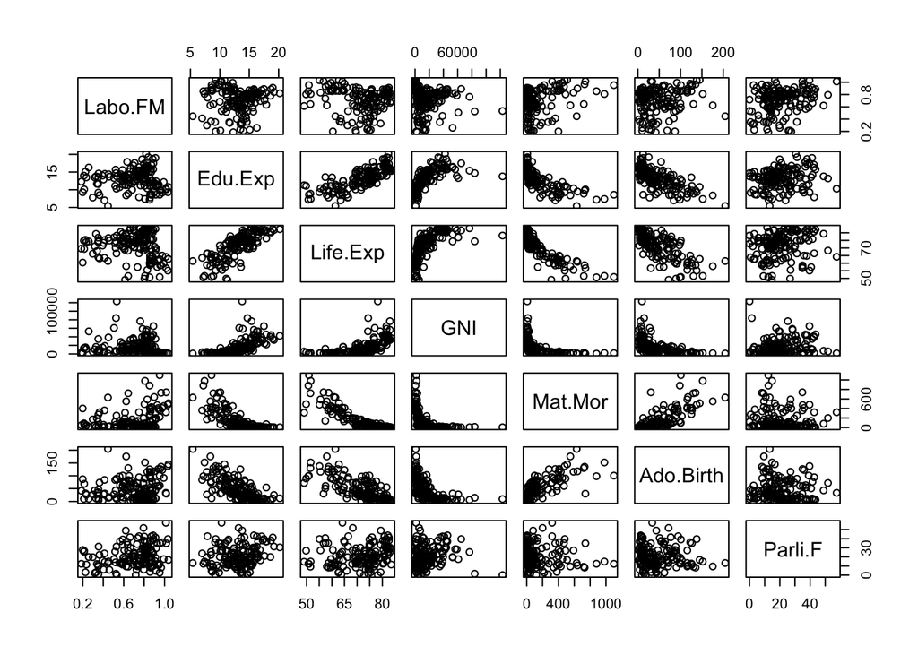

```r
#A matrix of scatterplots
pairs(human[-1],)
```

```r
cor_matrix<-cor(human[-1],)
round(cor_matrix, digits=2)
```

```
##           Labo.FM Edu.Exp Life.Exp   GNI Mat.Mor Ado.Birth Parli.F
## Labo.FM      1.00    0.05    -0.14 -0.02    0.24      0.12    0.25
## Edu.Exp      0.05    1.00     0.79  0.62   -0.74     -0.70    0.21
## Life.Exp    -0.14    0.79     1.00  0.63   -0.86     -0.73    0.17
## GNI         -0.02    0.62     0.63  1.00   -0.50     -0.56    0.09
## Mat.Mor      0.24   -0.74    -0.86 -0.50    1.00      0.76   -0.09
## Ado.Birth    0.12   -0.70    -0.73 -0.56    0.76      1.00   -0.07
## Parli.F      0.25    0.21     0.17  0.09   -0.09     -0.07    1.00
```

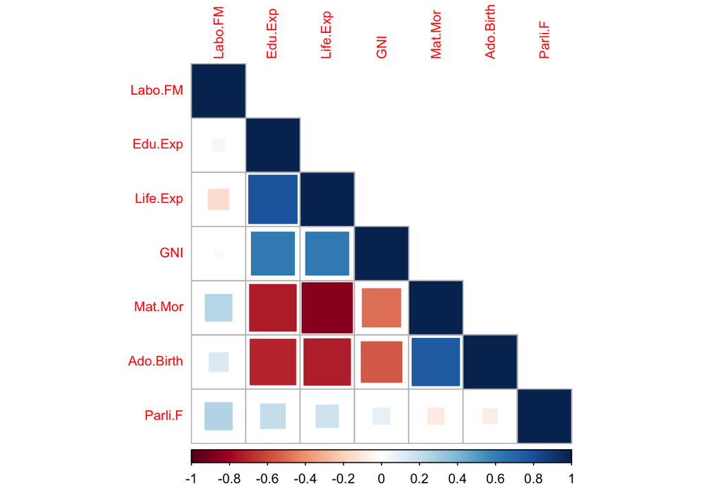

```r
corrplot(cor_matrix,method="square", type="lower",cl.pos="b", tl.pos="lt",tl.cex=0.8)
```

## Principal components analysis

Principal component analysis (PCA) is a technique for analyzing large datasets containing a high number of dimensions per observation. PCA can increase interpretability of data while preserving the maximum amount of information, and enabling the visualization of multidimensional data. [PCA](https://en.wikipedia.org/wiki/Principal_component_analysis)

First we attempt a PCA on the Human data without scaling the data first. This clusters the countries in the upper right corner with a lot of overlap so we can’t discern how the dimensions impact our observations. Only countries representing some extremes in the data are seen separate from the main cluster (eg. Qatar, Kuwait, Sierra Leon etc).

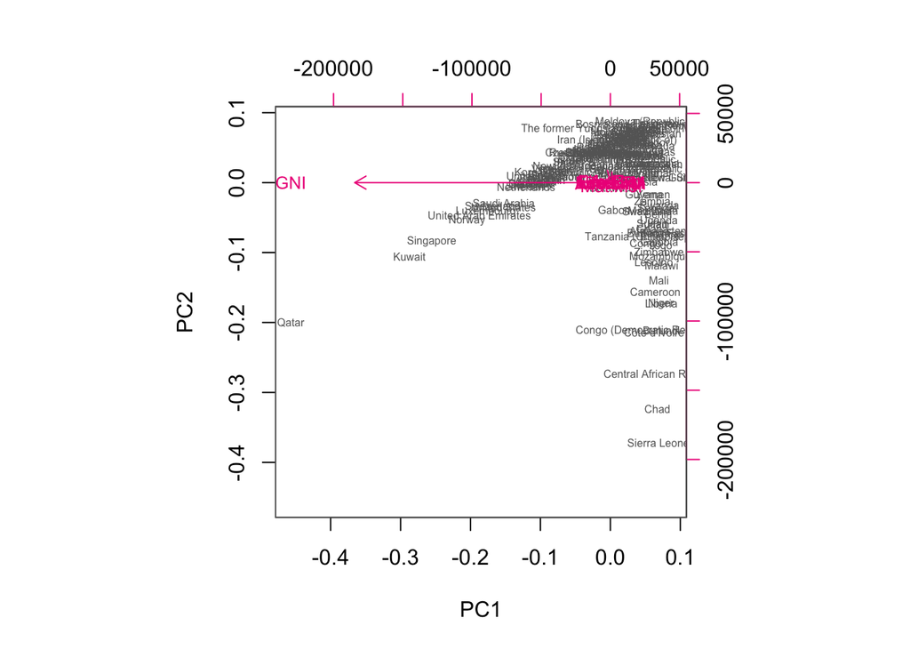

```r
library(readr)
human <- read.table("https://raw.githubusercontent.com/KimmoVehkalahti/Helsinki-Open-Data-Science/master/datasets/human2.txt", sep =",", header = TRUE)
pca_human <- prcomp(human)
biplot(pca_human, choices = 1:2, cex=c(0.5,0.8), col = c("grey40", "deeppink2"))
```

After standardizing the data we can see that the different countries are more spread out along the axes of the two principal components. The arrows represent the variables of the data. The variation in the data can be illustrated with the two principal components better after the standardization. We can see countries with high standards of living, long life expectancy and higher education clustered to the left and countries with lower standards of living, shorter life expectancy and lower education to the right in the graph. The wealthy countries are further divided in the vertical axes based on gender inequality with many Nordic and Western countries in the upper-left quadrant representing countries with better gender equality. Wealthy countries with poor gender equality are clustered toward th lower left quadrant e.g. the gulf countries. Afghanistan and Niger int he lower right corner of the PCA plot represent countries with low income and high gender inequality.

In a nut shell, we can view the PC1 as the ‘wealth and health’ axes and the PC2 as the ‘gender equality’ axes.

```r
# standardize the variables
human <- read.table("https://raw.githubusercontent.com/KimmoVehkalahti/Helsinki-Open-Data-Science/master/datasets/human2.txt", sep =",", header = TRUE)
human_std <- scale(human)

# print out summaries of the standardized variables
summary(human_std)
```

```
##     Edu2.FM           Labo.FM           Edu.Exp           Life.Exp
##  Min.   :-2.8189   Min.   :-2.6247   Min.   :-2.7378   Min.   :-2.7188
##  1st Qu.:-0.5233   1st Qu.:-0.5484   1st Qu.:-0.6782   1st Qu.:-0.6425
##  Median : 0.3503   Median : 0.2316   Median : 0.1140   Median : 0.3056
##  Mean   : 0.0000   Mean   : 0.0000   Mean   : 0.0000   Mean   : 0.0000
##  3rd Qu.: 0.5958   3rd Qu.: 0.7350   3rd Qu.: 0.7126   3rd Qu.: 0.6717
##  Max.   : 2.6646   Max.   : 1.6632   Max.   : 2.4730   Max.   : 1.4218
##       GNI             Mat.Mor          Ado.Birth          Parli.F
##  Min.   :-0.9193   Min.   :-0.6992   Min.   :-1.1325   Min.   :-1.8203
##  1st Qu.:-0.7243   1st Qu.:-0.6496   1st Qu.:-0.8394   1st Qu.:-0.7409
##  Median :-0.3013   Median :-0.4726   Median :-0.3298   Median :-0.1403
##  Mean   : 0.0000   Mean   : 0.0000   Mean   : 0.0000   Mean   : 0.0000
##  3rd Qu.: 0.3712   3rd Qu.: 0.1932   3rd Qu.: 0.6030   3rd Qu.: 0.6127
##  Max.   : 5.6890   Max.   : 4.4899   Max.   : 3.8344   Max.   : 3.1850
```

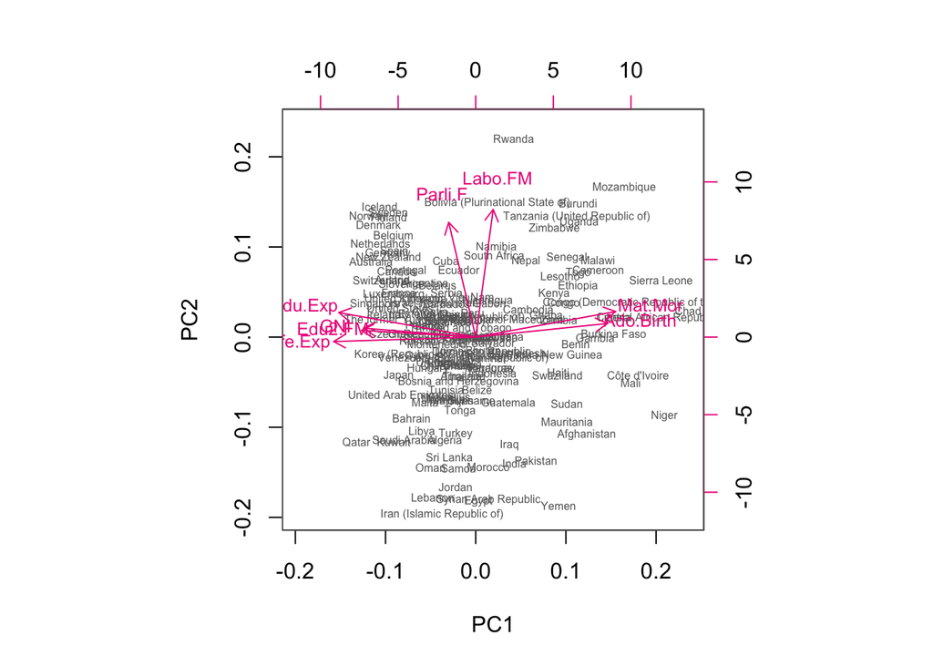

```r
# perform principal component analysis (with the SVD method)
pca_human <- prcomp(human_std)

# draw a biplot of the principal component representation and the original variables
biplot(pca_human, choices = 1:2, cex=c(0.5,0.8), col = c("grey40", "deeppink2"))
```

```r
library(dplyr)
library(tidyr)
library(readr)
library(ggplot2)
tea <- read.table("https://raw.githubusercontent.com/KimmoVehkalahti/Helsinki-Open-Data-Science/master/datasets/tea.csv",
                  sep = ",", header = T)
tea$Tea <- factor(tea$Tea)
tea$How <- factor(tea$How)
tea$how <- factor(tea$how)
tea$sugar <- factor(tea$sugar)
tea$where <- factor(tea$where)
tea$lunch <- factor(tea$lunch)

str(tea)
```

```
## 'data.frame':    300 obs. of  36 variables:
##  $ breakfast       : chr  "breakfast" "breakfast" "Not.breakfast" "Not.breakfast" ...
##  $ tea.time        : chr  "Not.tea time" "Not.tea time" "tea time" "Not.tea time" ...
##  $ evening         : chr  "Not.evening" "Not.evening" "evening" "Not.evening" ...
##  $ lunch           : Factor w/ 2 levels "lunch","Not.lunch": 2 2 2 2 2 2 2 2 2 2 ...
##  $ dinner          : chr  "Not.dinner" "Not.dinner" "dinner" "dinner" ...
##  $ always          : chr  "Not.always" "Not.always" "Not.always" "Not.always" ...
##  $ home            : chr  "home" "home" "home" "home" ...
##  $ work            : chr  "Not.work" "Not.work" "work" "Not.work" ...
##  $ tearoom         : chr  "Not.tearoom" "Not.tearoom" "Not.tearoom" "Not.tearoom" ...
##  $ friends         : chr  "Not.friends" "Not.friends" "friends" "Not.friends" ...
##  $ resto           : chr  "Not.resto" "Not.resto" "resto" "Not.resto" ...
##  $ pub             : chr  "Not.pub" "Not.pub" "Not.pub" "Not.pub" ...
##  $ Tea             : Factor w/ 3 levels "black","Earl Grey",..: 1 1 2 2 2 2 2 1 2 1 ...
##  $ How             : Factor w/ 4 levels "alone","lemon",..: 1 3 1 1 1 1 1 3 3 1 ...
```

[output cut: 22 more lines]

## Overview of the Tea data

- The Tea dataset contains the answers of a questionnaire on tea consumption.
- There are 300 observations and 36 variables in the dataset.

For the visualizing of the data we choose 6 interesting variables (how, How, pub, sugar, Tea and where):

- Most tea is consumed from tea bags as opposed to loose tea.
- Most people drink tea ‘alone’, that is, without lemon, milk or other additional flavoring.
- Only a small fraction drink their tea at a pub.
- The answers were almost split between sugar and no sugar use with tea.
- Earl Gray appears to be the most popular tea label in this poll.
- Most tea was bought from a chain store while only a small proportion of the respondents purchase tea from a tea shop.

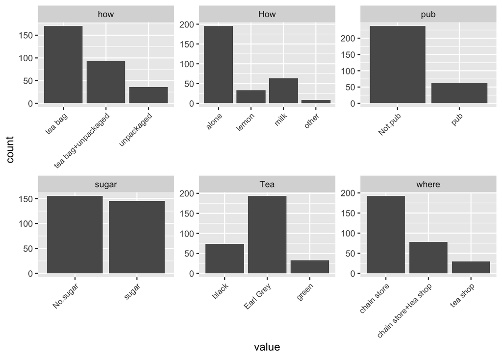

```r
library(ggplot2)
pivot_longer(tea, cols = 12:17) %>%
  ggplot+geom_bar()+(aes(value)) + facet_wrap("name", scales = "free")+theme(axis.text.x = element_text(angle = 45, hjust = 1, size = 8))
```

## Multiple correspondence analysis

In the Tea data we can observe the most common characteristics clustered around the center of the graph (Dim1=0, Dim2=0). The common tea consumer habit includes Eearl Grey bought from a chain store drank as is or with milk. The more distinguishing features of tea consumption are spread out from the center of the MCA factor map. Looking at the lower right corner we can identify a cluster of variables depicting a true tea devotee who buys his/her loose leaf green tea from a designated tea shop.

```r
library(dplyr)
library(tidyr)
library(FactoMineR)
tea_time<-tea[12:17]
mca <- MCA(tea_time, graph = FALSE)

# summary of the model
summary(mca)
```

```
##
## Call:
## MCA(X = tea_time, graph = FALSE)
##
##
## Eigenvalues
##                        Dim.1   Dim.2   Dim.3   Dim.4   Dim.5   Dim.6   Dim.7
## Variance               0.281   0.267   0.222   0.186   0.179   0.154   0.144
## % of var.             15.325  14.547  12.130  10.166   9.773   8.390   7.844
## Cumulative % of var.  15.325  29.872  42.002  52.168  61.941  70.331  78.176
##                        Dim.8   Dim.9  Dim.10  Dim.11
## Variance               0.136   0.115   0.087   0.062
## % of var.              7.422   6.259   4.751   3.391
## Cumulative % of var.  85.598  91.857  96.609 100.000
##
## Individuals (the 10 first)
##              Dim.1    ctr   cos2    Dim.2    ctr   cos2    Dim.3    ctr   cos2
## 1         | -0.382  0.173  0.140 | -0.266  0.088  0.068 |  0.223  0.074  0.048
## 2         | -0.330  0.129  0.070 | -0.202  0.051  0.026 |  0.758  0.862  0.369
## 3         | -0.435  0.224  0.313 | -0.210  0.055  0.073 |  0.108  0.018  0.019
## 4         | -0.578  0.396  0.534 | -0.159  0.032  0.040 | -0.314  0.148  0.157
## 5         | -0.435  0.224  0.313 | -0.210  0.055  0.073 |  0.108  0.018  0.019
## 6         | -0.435  0.224  0.313 | -0.210  0.055  0.073 |  0.108  0.018  0.019
## 7         | -0.435  0.224  0.313 | -0.210  0.055  0.073 |  0.108  0.018  0.019
## 8         | -0.330  0.129  0.070 | -0.202  0.051  0.026 |  0.758  0.862  0.369
## 9         |  0.256  0.078  0.037 |  0.683  0.584  0.265 |  0.362  0.197  0.075
## 10        |  0.544  0.351  0.181 |  0.461  0.266  0.130 |  0.785  0.923  0.376
##
## 1         |
## 2         |
## 3         |
## 4         |
## 5         |
## 6         |
## 7         |
## 8         |
## 9         |
## 10        |
##
## Categories (the 10 first)
```

[output cut: 16 more lines]

```
## green       0.337   0.937   0.014   2.050 |
## alone       0.021   0.021   0.001   0.484 |
## lemon      -1.325  14.468   0.217  -8.053 |
## milk        0.342   1.845   0.031   3.053 |
## other       2.015   9.131   0.126   6.128 |
## No.sugar    0.577  12.894   0.356  10.317 |
##
## Categorical variables (eta2)
##             Dim.1 Dim.2 Dim.3
## pub       | 0.039 0.137 0.123 |
## Tea       | 0.075 0.192 0.425 |
## How       | 0.119 0.166 0.340 |
## sugar     | 0.052 0.006 0.356 |
## how       | 0.686 0.445 0.040 |
## where     | 0.716 0.653 0.051 |
```

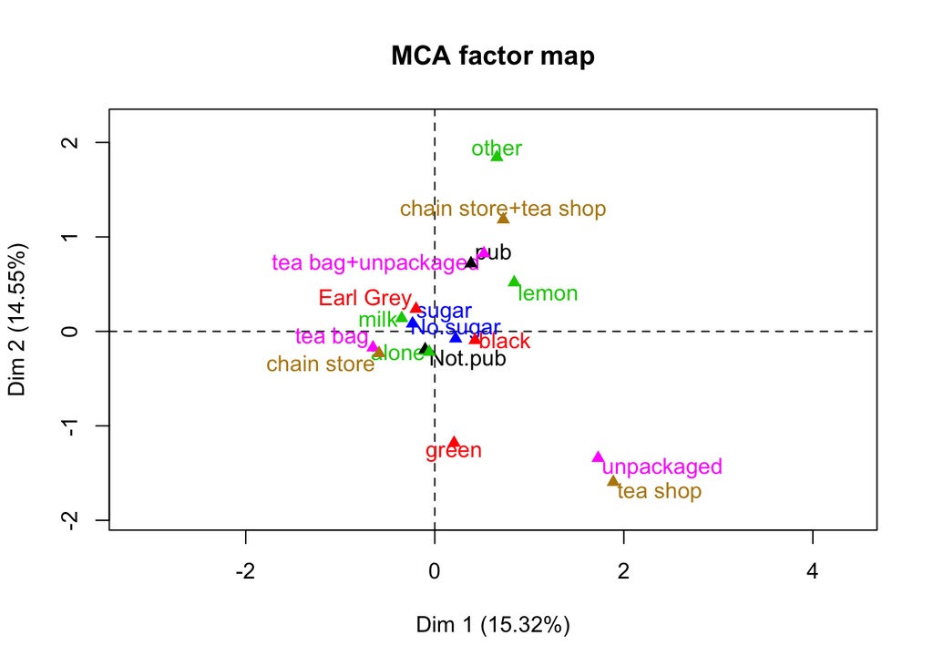

```r
# visualize MCA
plot(mca, invisible=c("ind"), graph.type = "classic", habillage = "quali")
```

*Countless cups of tea were consumed during the completion of this assignment*